# Which markets are most promising for e-commerce businesses?

Project 3

SID 530823715

University of Sydney | DATA1001 | 10 2023

```r
#thanks to https://stackoverflow.com/questions/42546001/how-to-change-colors-and-attributes-of-table-of-contents-in-r-markdown-html-docu, https://www.coder.work/article/1118576 and https://blog.csdn.net/qq_44156869/article/details/108556582 for theme designing

library(tidyverse)
library(rafalib)

ukretail <- read_csv("D:/Financial M/DATA1001/individual/project 3/uk_retail.csv")

# data cleaning

a = nrow(ukretail)
cancelled_retail <- filter(ukretail, substr(ukretail$TransactionNo, 1, 1) == "C")
b = nrow(cancelled_retail)

c = b / a * 100

ukretail <- subset(ukretail, substr(ukretail$TransactionNo, 1, 1) != "C") #delete data for cancelled transactions
ukretail <- subset(ukretail, ukretail$Country != "Unspecified")

# Add a new column of total amount of payment
ukretail$Payment <- ukretail$Price * ukretail$Quantity
ukretail <- cbind(ukretail[1:6], ukretail$Payment, ukretail[7:8])
colnames(ukretail)[7] = "Payment"

country <- aggregate(ukretail$Country, by = list(ukretail$Country), FUN = length)
colnames(country)[1] = "Country"
colnames(country)[2] = "Number of Transactions"

#make it a descending order
country <- arrange(country, desc(country$`Number of Transactions`))

# add a new column named "Quantity"
country$Quantity <- c(0 * nrow(country))
country <- cbind(country[1:2], country$Quantity)
colnames(country)[3] = "Quantity"

# add a new column named "Payment"
country$Payment <- c(0 * nrow(country))
country <- cbind(country[1:3], country$Payment)
colnames(country)[4] = "Payment"

# find the total amount of product purchased
for(i in 1 : nrow(country)){
  for(j in 1: nrow(ukretail)){
    if (ukretail$Country[j] == country$Country[i]){
      country$Quantity[i] <- country$Quantity[i] + ukretail$Quantity[j]
    }
  }
}

# find the total payment of product purchased
for(i in 1 : nrow(country)){
  for(j in 1: nrow(ukretail)){
    if (ukretail$Country[j] == country$Country[i]){
      country$Payment[i] <- country$Payment[i] + ukretail$Payment[j]
    }
  }
}
```

# 1 Client

Miss Louisa (Jean-Charles) Guelcé

Head Of Marketing at Rex London, an online gift shop

[linkedin](https://www.linkedin.com/in/louisaguelce/)

# 2 Recommendation

The most promising markets for e-commerce are Germany, Switzerland, UK and Australia. More efforts can be devoted into these markets to expand until they reach their maturity.

# 3 Evidence

## 3.1 Initial Data Analysis

The data set is from Kaggle.com, containing one-year transaction information for a London-based e-commerce retailer. Each row represents a transaction, including a Transaction number(C stands for cancellation), the date when the transaction is made, number of product purchased, price for each unit of product in ￡, the quantity for each product, CustomerNo and resided country for each customer.

## 3.2 Transaction data from Kaggle (given data)

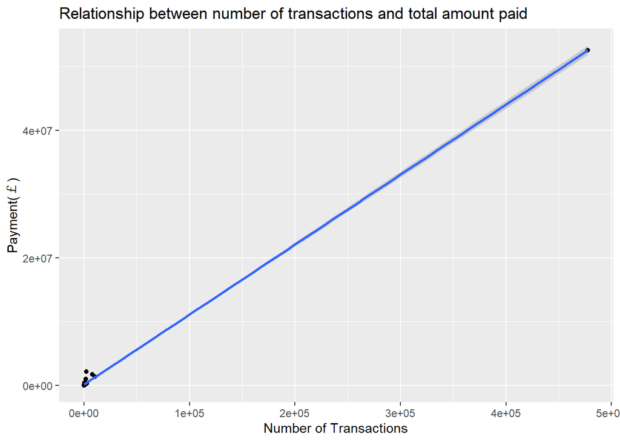

```r
#Linear Regression Line
ggplot(country, aes(x = country$`Number of Transactions`, y = country$Payment)) +
  geom_point() +
  geom_smooth(method = "lm") +
  xlab("Number of Transactions") +
  ylab("Payment(￡)") +
  ggtitle("Relationship between number of transactions and total amount paid")
```

```r
head(country, 10)
```

```
##           Country Number of Transactions Quantity    Payment
## 1  United Kingdom                 477771  4667890 52524658.5
## 2          France                  10393   118599  1330652.9
## 3         Germany                  10240   120416  1371543.3
## 4            EIRE                   7807   146734  1713411.0
## 5         Belgium                   2507    23730   272131.9
## 6           Spain                   2386    23500   281012.3
## 7     Netherlands                   2326   200834  2151553.6
## 8     Switzerland                   2303    30826   361969.2
## 9        Portugal                   1838    16728   176110.4
## 10      Australia                   1631    85754   995607.9
```

By going through linear modelling, the positive linear correlation between number of transactions and amount of payment can be verified. Therefore, the conclusion can be drawn that if number of transaction increases, the amount that the business earned increases. Based on this, the ten most promising markets for e-commerce would be UK, France, Germany, EIRE, Belgium, Spain, Netherlands, Switzerland, Portugal and Australia.

## 3.3 Purchasing Power Index from NUMBEO

```r
library(readxl)
PPI <- read_excel("PPI_2020.xls")
head(PPI, 10)
```

```
## # A tibble: 10 × 3
##     Rank Country       `Purchasing Power Index`
##    <dbl> <chr>                            <dbl>
##  1     1 Switzerland                      120.
##  2     2 Qatar                            112.
##  3     3 United States                    110.
##  4     4 Australia                        107.
##  5     5 Germany                          102.
##  6     6 Sweden                           102.
##  7     7 Denmark                          101.
##  8     8 Saudi Arabia                     100
##  9     9 Finland                           99.9
## 10    10 Canada                            95.1
```

Purchasing Power Index measures the purchasing power of a certain currency, showing one aspect of residences’ living standard. With a higher PPI, residences from corresponding country can purchase more with their disposable income. Business can earn more as revenue. From this perspective, the ten most promising markets for e-commerce would be Switzerland, Qatar, US,Australia, Germany, Sweden, Denmark, Saudi Arabia, Finland and Canada.

```r
#find corresponding PPT ranking
country$`PPI ranking` <- c(0 * nrow(country))
country <- cbind(country[1:4], country$`PPI ranking`)
colnames(country)[5] = "PPI ranking"

for(i in 1 : nrow(country)){
  for(j in 1: nrow(PPI)){
    if (PPI$Country[j] == country$Country[i]){
      country$`PPI ranking`[i] <- PPI$Rank[j]
    }
  }
}

#grade each country for its number of transactions and PPI, each weighted 50%
country <- arrange(country, desc(country$`Number of Transactions` ))

country$`PPI ranking`[4] = 23
country$`PPI ranking`[22] = 3
country <- filter(country, country$`PPI ranking` > 0)

country$Total <- c(0 * nrow(country))
country <- cbind(country[1:5], country$Total)
colnames(country)[6] = "Total"

for(i in 1 : nrow(country)){
  country$Total[i] <- i * 0.5 + country$`PPI ranking`[i] * 0.5
}
country <- arrange(country, country$Total)
head(country)
```

```
##          Country Number of Transactions Quantity    Payment PPI ranking Total
## 1        Germany                  10240   120416  1371543.3           5   4.0
## 2    Switzerland                   2303    30826   361969.2           1   4.5
## 3 United Kingdom                 477771  4667890 52524658.5          12   6.5
## 4      Australia                   1631    85754   995607.9           4   7.0
## 5    Netherlands                   2326   200834  2151553.6          14  10.5
## 6        Belgium                   2507    23730   272131.9          18  11.5
```

If each country is graded with number of transactions and PPI each weighted 50%, the conclusion will be more reasonable as number of transactions during the year can represent residences’ willingness to purchase and PPI represents their purchase power with their currency. If the country has the 10th greatest number of transactions and 10th highest PPI, its “Total” would be 10 as well. To find the most promising markets, “Total” greater than 10 are excluded. From this, the most promising markets for e-commerce would be Germany, Switzerland, UK and Australia. Further research can be done to make this conclusion more reliable.

# 4 Acknowledgements

This report cannot be written without information from Kaggle, Linkedin and NUMBEO. And I would like to give my sincere thanks to all teaching team members for DATA1001 and 8:00-10:00Lab. I am also grateful for the accompany and patience given by my mother. Those appeared to be very important when I face downtime (not only for my academic life).

# 5 Appendix

## 5.1 Cilent

Rex London is a UK based online gift shop, indicating this retailer can make a reference for its marketing decision from the given data set. Being the head of Rex’s marketing department, Miss Guelcé may find this report helpful. For this client, professional terminology can be brought up e.g PPI.

## 5.2 Statistical Analysis

To see if total amount of payment grows as number of transactions or quantity of products sold is increasing. (p < 0.05 for significant)

### 5.2.1 Payment vs Transactions

Hypothesis:

H0-There exists a positive linear correlation between number of transactions and amount of payment.

H1-Such correlation does not exist.

Assumption: Each transaction made was independent of each other.

```r
line1 <- lm(Payment ~ `Number of Transactions`, data = country)
summary(line1)
```

```
##
## Call:
## lm(formula = Payment ~ `Number of Transactions`, data = country)
##
## Residuals:
##     Min      1Q  Median      3Q     Max
## -207009 -157893 -146487  -42322 1737476
##
## Coefficients:
##                           Estimate Std. Error t value Pr(>|t|)
## (Intercept)              1.590e+05  7.005e+04   2.271   0.0305 *
## `Number of Transactions` 1.096e+02  8.288e-01 132.298   <2e-16 ***
## ---
## Signif. codes:  0 '***' 0.001 '**' 0.01 '*' 0.05 '.' 0.1 ' ' 1
##
## Residual standard error: 388700 on 30 degrees of freedom
## Multiple R-squared:  0.9983, Adjusted R-squared:  0.9982
## F-statistic: 1.75e+04 on 1 and 30 DF,  p-value: < 2.2e-16
```

```r
cor(country$`Number of Transactions`, country$Payment)
```

```
## [1] 0.9991441
```

### 5.2.2 Payment vs Quantity

Hypothesis:

H0-There exists a positive linear correlation between quantity of products purchased and amount of payment.

H1-Such correlation does not exist.

Assumption: Each transaction made was independent of each other.

```r
line2 <- lm(Payment ~ Quantity, data = country)
summary(line2)
```

```
##
## Call:
## lm(formula = Payment ~ Quantity, data = country)
##
## Residuals:
##     Min      1Q  Median      3Q     Max
## -109631   -1613    -423    3297   60938
##
## Coefficients:
##              Estimate Std. Error  t value Pr(>|t|)
## (Intercept) 1.479e+03  4.392e+03    0.337    0.739
## Quantity    1.125e+01  5.310e-03 2119.087   <2e-16 ***
## ---
## Signif. codes:  0 '***' 0.001 '**' 0.01 '*' 0.05 '.' 0.1 ' ' 1
##
## Residual standard error: 24290 on 30 degrees of freedom
## Multiple R-squared:      1,  Adjusted R-squared:      1
## F-statistic: 4.491e+06 on 1 and 30 DF,  p-value: < 2.2e-16
```

```r
cor(country$Quantity, country$Payment)
```

```
## [1] 0.9999967
```

## 5.3 Limitations

1. Cancelled transactions are out of consideration.
2. Data collected are limited with a time length. As the market is dynamic and people’s purchasing behaviors may change during the pandemic, the conclusion may be out of date.